# WiDS : Sentiment Analysis Workshop Part 2

Ankita Guha

8/20/2023

```r
# Libraries
library(tm)
library(quanteda)
```

```r
library(NLP)
library("SnowballC")
library("wordcloud")
library("RColorBrewer")
library("ggplot2")
```

## Reading the Data File & Processing it for further analysis

```r
# Setting the working directory
setwd("~/Sentiment Analysis Workshop - WiDS")
AmazonReviews <- read.csv('./data/amazon_reviews.csv')

# Excluding NA
AmazonReviews <- na.omit(AmazonReviews)

# Corpus
Reviews <- Corpus(VectorSource(AmazonReviews$reviewText))

# Text Post Processing : Conversion to lower Case
Reviews <- tm_map(Reviews, content_transformer(tolower))
# Removing Punctuation
Reviews <- tm_map(Reviews, removePunctuation)
# Remove Stop Words
Reviews <- tm_map(Reviews, removeWords, stopwords("en"))
# Remove Numbers
Reviews <- tm_map(Reviews, removeNumbers)
# Remove context specific words
Reviews <- tm_map(Reviews, removeWords,c("amazon", "amazons"))
# Remove Stem Document
Reviews <- tm_map(Reviews, stemDocument)
# Replace "/", "@" and "|" with space
# toSpace <- content_transformer(function (x , pattern ) gsub(pattern, " ", x))
# Reviews <- tm_map(Reviews, toSpace, "/")
# Reviews <- tm_map(Reviews, toSpace, "@")
# Reviews <- tm_map(Reviews, toSpace, "\\|")

# Eliminate extra white space
Reviews <- tm_map(Reviews, stripWhitespace)
# Term Document Matrix
Reviews_TDM <- TermDocumentMatrix(Reviews)
Reviews_TDM <- as.matrix(Reviews_TDM)

Reviews_TDM_V <- sort(rowSums(Reviews_TDM), decreasing = TRUE)

TDM <- data.frame(word=names(Reviews_TDM_V), freq=Reviews_TDM_V)
```

## Print the dimension of the Matrix

Note the number of rows and columns in this Matrix for our further analysis.There are 7260 terms in 4915 documents.It helps in understanding the words and their frequencies.

```r
dim(Reviews_TDM)
```

```
## [1] 7260 4915
```

```r
dim(TDM)
```

```
## [1] 7260    2
```

```r
#dim(Reviews_DTM)
```

*Note*: In real life data this will not happen and you will have to remove the Sparse terms so that most of the terms that are 0s are removed from further analysis.

```r
frequencies = TermDocumentMatrix(TDM)
frequencies
```

```
## <<TermDocumentMatrix (terms: 7518, documents: 2)>>
## Non-/sparse entries: 7518/7518
## Sparsity           : 50%
## Maximal term length: 120
## Weighting          : term frequency (tf)
```

Play around with the value of Sparse and check how the TDM will behave. Sparse = 0.99 will remove terms that are more sparse, retaining most of the terms within the document.

```r
#removeSparseTerms(<yourTDMorDTM>, sparse = 0.01)
```

## Dimension Reduction Using Hierarchical Clustering

### Euclidean Distance with Complete Clustering Criteria

The Dissimilarity within the Corpus is calculated using the Euclidean Method. Next the Hierarchical Clustering is performed using either of the agglomeration method such as (complete, average, single, Ward.D).

```r
#sample(Reviews_TDM, 500)
hc <- hclust(d = dist((TDM), method = "euclidean"), method = "complete")
```

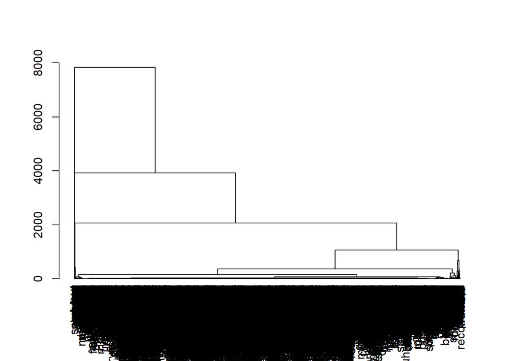

```r
hcd = as.dendrogram(hc)
plot(hcd)
```

```r
#plot(hcd, cex = 5, hang = -2) # Change it to 1 and see the difference in the cut on the tree
```